# Project

## Introduction

The COVID-19 pandemic, also known as the coronavirus pandemic, is a global pandemic of coronavirus disease 2019 (COVID-19) caused by severe acute respiratory syndrome coronavirus 2 (SARS-CoV-2). The novel virus was first identified from an outbreak in Wuhan, China, in December 2019. Attempts to contain it there failed, allowing the virus to spread worldwide. The World Health Organization (WHO) declared a Public Health Emergency of International Concern on 30 January 2020 and a pandemic on 11 March 2020. As of 15 June 2022, the pandemic had caused more than 536 million cases and 6.31 million confirmed deaths, making it one of the deadliest in history.

COVID-19 symptoms range from undetectable to deadly, but most commonly include fever, dry cough, and fatigue. Severe illness is more likely in elderly patients and those with certain underlying medical conditions. COVID‑19 transmits when people breathe in air contaminated by droplets and small airborne particles containing the virus. The risk of breathing these in is highest when people are in close proximity, but they can be inhaled over longer distances, particularly indoors. Transmission can also occur if contaminated fluids reach the eyes, nose or mouth, and, rarely, via contaminated surfaces. Infected persons are typically contagious for 10 days, and can spread the virus even if they do not develop symptoms. Mutations have produced many strains (variants) with varying degrees of infectivity and virulence.

## Presentation and description of the problem

Including some tables I will be representing some selected data relevant to the covid situation in Slovenia, and in the world overall. Additionally using plots I will visualize certain interesting data.

## Presentation of the data

### Data pt. 1

In the first dataset we have the total information summed up until July 27th 2020.

| Country | Continent | Population | TotalCases | TotalDeaths | TotalRecovered | ActiveCases | Tot.Cases.1M.pop | Deaths.1M.pop | TotalTests | Tests.1M.pop | WHO.Region | Lat | Long |
| --- | --- | --- | --- | --- | --- | --- | --- | --- | --- | --- | --- | --- | --- |
| Afghanistan | Asia | 39009447 | 36896 | 1298 | 25840 | 9758 | 946 | 33 | 90396 | 2317 | EasternMediterranean | 33.93911 | 67.709953 |
| Albania | Europe | 2877470 | 6016 | 188 | 3155 | 2673 | 2091 | 65 | 38997 | 13553 | Europe | 41.1533 | 20.1683 |
| Algeria | Africa | 43926079 | 33626 | 1273 | 23238 | 9115 | 766 | 29 |  |  | Africa | 28.0339 | 1.6596 |
| Andorra | Europe | 77278 | 944 | 52 | 828 | 64 | 12216 | 673 | 3750 | 48526 | Europe | 42.5063 | 1.5218 |
| Angola | Africa | 32956300 | 1483 | 64 | 520 | 899 | 45 | 2 | 64747 | 1965 | Africa | -11.2027 | 17.8739 |
| Antigua and Barbuda | North America | 98010 | 92 | 3 | 76 | 13 | 939 | 31 | 1500 | 15305 | Americas | 17.0608 | -61.7964 |
| Argentina | South America | 45236884 | 228195 | 4251 | 99852 | 124092 | 5044 | 94 | 794544 | 17564 | Americas | -38.4161 | -63.6167 |
| Armenia | Asia | 2963811 | 39819 | 772 | 31556 | 7491 | 13435 | 260 | 171600 | 57898 | Europe | 40.0691 | 45.0382 |
| Aruba | North America | 106812 | 263 | 3 | 114 | 146 | 2462 | 28 | 14047 | 131511 |  | 12.52111 | -69.968338 |
| Australia | Australia/Oceania | 25528864 | 19890 | 255 | 10941 | 8694 | 779 | 10 | 4631419 | 181419 | WesternPacific | -35.4735 | 149.0124 |

[output cut: 187 more lines]

- **Country**
  - The Country that the data is show for
- **Continent**
  - The Continent where the country is located
- **Population**
  - Population of the country at the given moment (last updated 27th July 2020)
- **Total Cases**
  - Total confirmed positive covid cases at the given moment (last updated 27th July 2020)
- **Total Deaths**
  - Total confirmed deaths from covid at the given moment (last updated 27th July 2020)
- **Total Recovered**
  - Total recovered people from covid at the given moment (last updated 27th July 2020)
- **Active cases**
  - Current active covid cases (last updated 27th July 2020)
- **Total Cases per 1 Million population**
  - Total confirmed positive covid cases per 1 Million population at the given moment (last updated 27th July 2020)
- **Total Deaths per 1 Million population**
  - Total confirmed deaths from covid per 1 Million population at the given moment (last updated 27th July 2020)
- **Total Tests**
  - Total covid tests distributed at the given moment (last updated 27th July 2020)
- **Total Tests per 1 Million population**
  - Total covid tests distributed at the given moment per 1 Million population(last updated 27th July 2020)
- **WHO Region**
  - The region the Country belongs to according to World Health Organization (WHO)
- **Lat**
  - Latitude of the Country
- **Long**
  - Longitude of the Country

Some interesting insights from the data set are shown:

country_total$Continent

| n | missing | distinct |
| --- | --- | --- |
| 197 | 0 | 6 |

| lowest : | Africa | Asia | Australia/Oceania | Europe | North America |
| --- | --- | --- | --- | --- | --- |
| highest: | Asia | Australia/Oceania | Europe | North America | South America |

```
 Value                 Africa              Asia Australia/Oceania            Europe
 Frequency                 51                48                 6                48
 Proportion             0.259             0.244             0.030             0.244

 Value          North America     South America
 Frequency                 30                14
 Proportion             0.152             0.071
```

### Data pt.2

In the second data table named Daily_Total, we have data about how the covid situation progressed each day worldwide up until 27th July 2020.

| Date | Confirmed | Deaths | Recovered | Active | New.cases | New.deaths | New.recovered | No..of.countries |
| --- | --- | --- | --- | --- | --- | --- | --- | --- |
| 1/22/2020 | 555 | 17 | 28 | 510 | 0 | 0 | 0 | 6 |
| 1/23/2020 | 654 | 18 | 30 | 606 | 99 | 1 | 2 | 8 |
| 1/24/2020 | 941 | 26 | 36 | 879 | 287 | 8 | 6 | 9 |
| 1/25/2020 | 1434 | 42 | 39 | 1353 | 493 | 16 | 3 | 11 |
| 1/26/2020 | 2118 | 56 | 52 | 2010 | 684 | 14 | 13 | 13 |
| 1/27/2020 | 2927 | 82 | 61 | 2784 | 809 | 26 | 9 | 16 |
| 1/28/2020 | 5578 | 131 | 107 | 5340 | 2651 | 49 | 46 | 16 |
| 1/29/2020 | 6166 | 133 | 125 | 5908 | 588 | 2 | 18 | 18 |
| 1/30/2020 | 8234 | 171 | 141 | 7922 | 2068 | 38 | 16 | 20 |
| 1/31/2020 | 9927 | 213 | 219 | 9495 | 1693 | 42 | 78 | 24 |

[output cut: 178 more lines]

- **Date**
  - The date that the data is presented about
- **Confirmed**
  - Total confirmed positive covid cases on the given date
- **Deaths**
  - Total confirmed deaths from covid on the given date
- **Recovered**
  - Total recovered people from covid on the given date
- **Active**
  - Current active covid cases on the given date
- **New Cases**
  - Number of new confirmed positive covid cases in the last 24h
- **New Deaths**
  - Number of new confirmed deaths from in the last 24h
- **New Recovered**
  - Number of people that have recovered from covid in the last 24h
- **Number of Countries**
  - Number of countries currently afffected by covid

Some interesting insights from the data set are shown:

daily_total$New.cases

```
        n  missing distinct     Info     Mean      Gmd      .05      .10      .25
      188        0      188        1    87771    83921    648.2   1858.4   5568.5
      .50      .75      .90      .95
  81114.0 131502.5 207056.1 230271.9
```

lowest : 0 99 287 323 421 , highest: 252544 255545 280647 281164 282756

daily_total$New.deaths

| n | missing | distinct | Info | Mean | Gmd | .05 | .10 | .25 | .50 | .75 | .90 | .95 |
| --- | --- | --- | --- | --- | --- | --- | --- | --- | --- | --- | --- | --- |
| 188 | 0 | 185 | 1 | 3479 | 2858 | 30.2 | 65.4 | 250.8 | 4116.0 | 5346.0 | 6517.8 | 6887.1 |

lowest : 0 1 2 4 5 , highest: 7629 7902 8312 8890 9966

### Data pt.3

And our third and biggest data set named Country_Daily contains data of how covid progressed in each province and county, every day for the first 6months of covid. (22nd January - 27th July 2020)

| Province.State | Country.Region | Lat | Long | Date | Confirmed | Deaths | Recovered | Active | WHO.Region |
| --- | --- | --- | --- | --- | --- | --- | --- | --- | --- |
|  | Afghanistan | 33.93911 | 67.709953 | 1/22/2020 | 0 | 0 | 0 | 0 | Eastern Mediterranean |
|  | Albania | 41.1533 | 20.1683 | 1/22/2020 | 0 | 0 | 0 | 0 | Europe |
|  | Algeria | 28.0339 | 1.6596 | 1/22/2020 | 0 | 0 | 0 | 0 | Africa |
|  | Andorra | 42.5063 | 1.5218 | 1/22/2020 | 0 | 0 | 0 | 0 | Europe |
|  | Angola | -11.2027 | 17.8739 | 1/22/2020 | 0 | 0 | 0 | 0 | Africa |
|  | Antigua and Barbuda | 17.0608 | -61.7964 | 1/22/2020 | 0 | 0 | 0 | 0 | Americas |
|  | Argentina | -38.4161 | -63.6167 | 1/22/2020 | 0 | 0 | 0 | 0 | Americas |
|  | Armenia | 40.0691 | 45.0382 | 1/22/2020 | 0 | 0 | 0 | 0 | Europe |
| Australian Capital Territory | Australia | -35.4735 | 149.0124 | 1/22/2020 | 0 | 0 | 0 | 0 | Western Pacific |
| New South Wales | Australia | -33.8688 | 151.2093 | 1/22/2020 | 0 | 0 | 0 | 0 | Western Pacific |

[output cut: 990 more lines]

- **Province**
  - The Province that the data is show for
- **Country**
  - The Country that the province is located
- **Date**
  - The date that the data is presented about
- **Confirmed**
  - Total confirmed positive covid cases on the given date
- **Deaths**
  - Total confirmed deaths from covid on the given date
- **Recovered**
  - Total recovered people from covid on the given date
- **Active**
  - Current active covid cases on the given date
- **WHO Region**
  - The region the Country belongs to according to World Health Organization (WHO)

Some interesting insights from the data set are shown:

country_daily$WHO.Region

| n | missing | distinct |
| --- | --- | --- |
| 49068 | 0 | 6 |

| lowest : | Africa | Americas | Eastern Mediterranean | Europe | South-East Asia |
| --- | --- | --- | --- | --- | --- |
| highest: | Americas | Eastern Mediterranean | Europe | South-East Asia | Western Pacific |

```
 Value                     Africa              Americas Eastern Mediterranean
 Frequency                   9024                  8648                  4136
 Proportion                 0.184                 0.176                 0.084

 Value                     Europe       South-East Asia       Western Pacific
 Frequency                  15040                  1880                 10340
 Proportion                 0.307                 0.038                 0.211
```

### Last update: 27 July 2020

| Date | Confirmed | Deaths | Recovered | Active |
| --- | --- | --- | --- | --- |
| 7/27/2020 | 16480485 | 654036 | 9468087 | 6358362 |

## Exploratory Data Analysis and Visualization

### Number of cases & Number of deaths

In this plot we are going to have to re-scale the confirmed cases and confirmed deaths since the amount of deaths is significantly lower and the line won’t be as visible. However we are including scales on both sides for actual number representation.

[figure not shown]

We can see in this plot the cases per day, but since we have a lot of days it looks a bit messy. In the following plot we will try to visualize the data per month and make it smoother for easier understanding

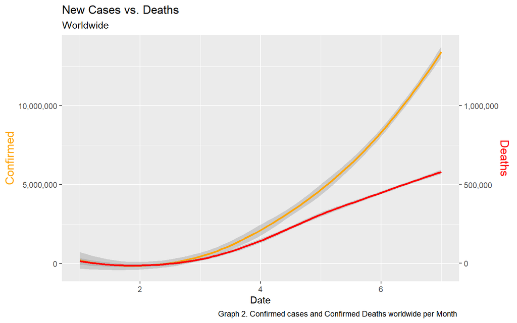

Here we can see the total cases and deaths for Slovenia

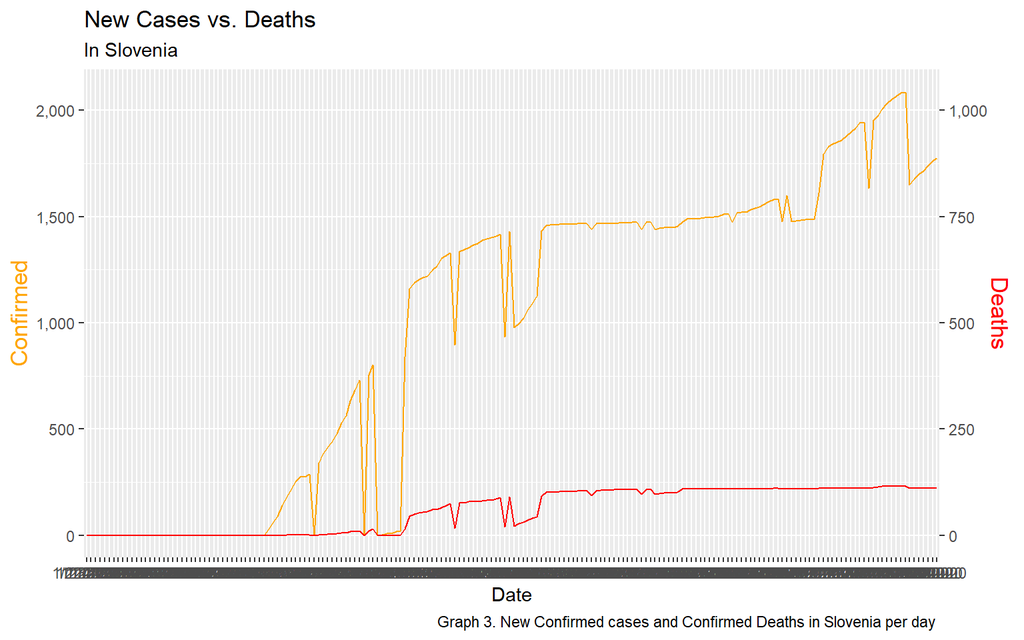

### *Correlation between number of Recovered cases and Death cases*

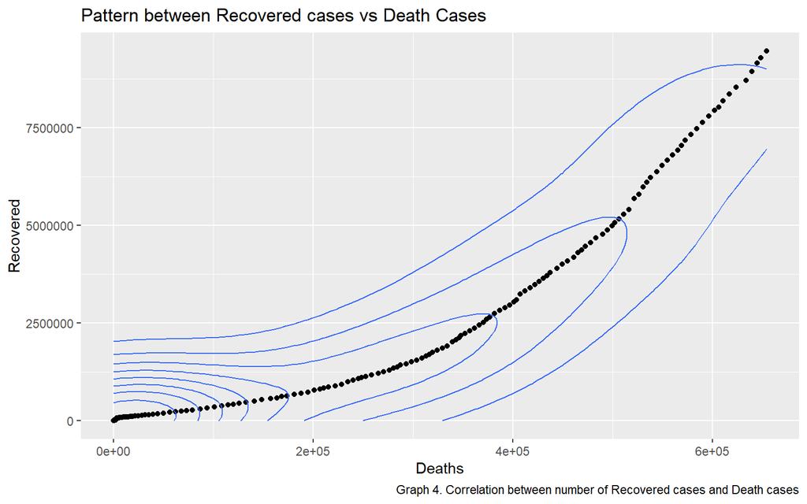

We can see that for the first half (first 3 months) we have for every death case, 4 times recovered cases, and in the second part the ratio of recovered cases versus deaths has increased, meaning people started going into quarantine to prevent spreading, and the world learned how to help prevent the cases geting into criticical states that can result with deaths.

### *Correlation between geographical locations and covid*

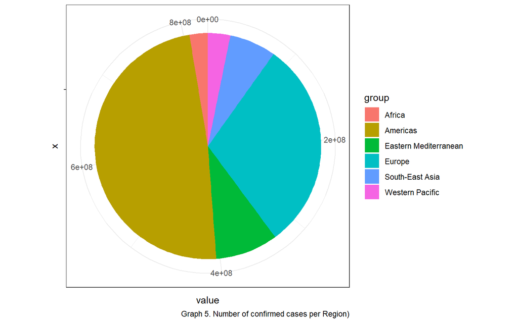

From the chart we can see that almost half of the confirmed cases came from North and South America, and the least from Africa and Western Pacific.

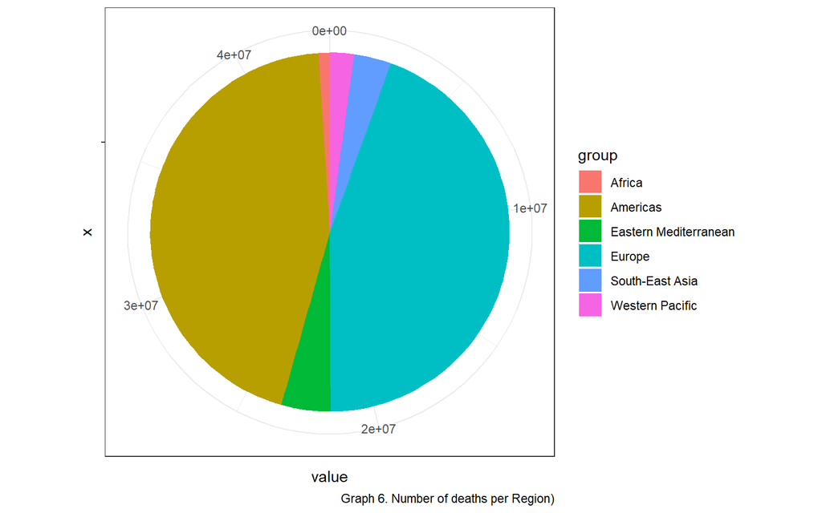

### *Cases per capita evaluation*

The number of deaths and cases is also irrelevant without the knowledge of how many people live in that country. We want to see which countries had the most cases per capita and deaths per capita.

[figure not shown]

### *Covid Tests*

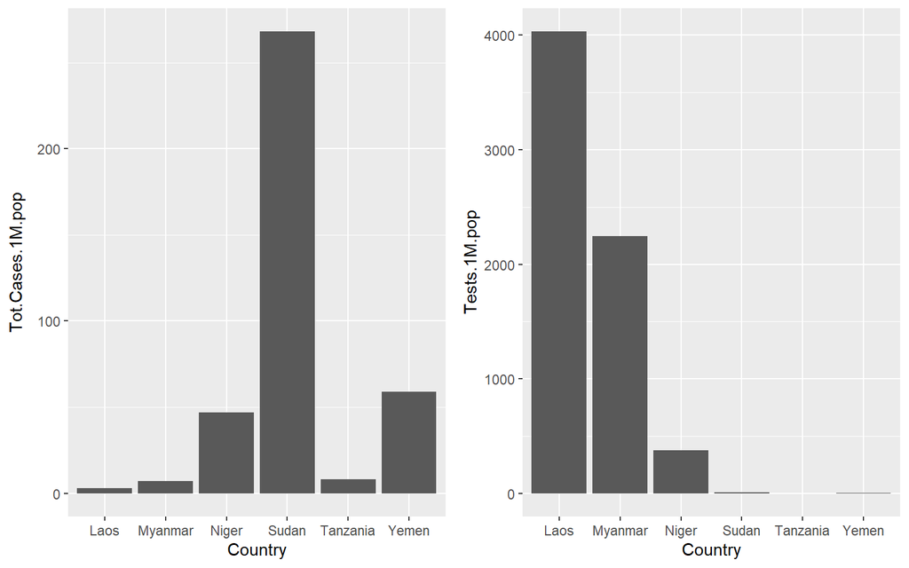

### *Map Visuals*

We will make use of a map plotting and visually represent how many cases in total every country had. Here we can see the number of total cases per country. Every gray point represents > 10.000 cases

[interactive chart not shown]

## References

Barnier, Julien. 2022. “Rmdformats.” GitHub. https://github.com/juba/rmdformats.

Contributors, Wikipedia. 2019. “Exploratory Data Analysis.” Wikipedia; Wikimedia Foundation. https://en.wikipedia.org/wiki/Exploratory_data_analysis.

“COVID-19 Dataset.” n.d. www.kaggle.com. https://www.kaggle.com/datasets/imdevskp/corona-virus-report.

Machlis, Sharon. 2021. “Astonishingly Easy Mapping in r with Mapview.” InfoWorld. https://www.infoworld.com/article/3644848/astonishingly-easy-mapping-in-r-with-mapview.html.